# Unit 4.3: Monte Carlo Integration and Importance Sampling

Dr. Manoj C. Patil

2026-09-30

# 1 Why Monte Carlo?

Quadrature (Unit 4.2) puts points on a grid. In $d$ dimensions the grid needs (points per axis)$^d$ evaluations, which quickly becomes impossible.

Monte Carlo uses **random points** instead. Its error is about $1/\sqrt n$ **no matter how many dimensions** the integral has.

# 2 Monte Carlo Integration

## 2.1 The idea

An integral is an expectation, and an expectation is estimated by an average. If $X \sim f$:

$$\theta = \int g(x) f(x)\,dx = E[g(X)]
\quad\Longrightarrow\quad
\hat\theta = \frac{1}{n}\sum_{i=1}^n g(X_i)$$

Two special cases cover most problems:

- **Integral on $[a,b]$:** $\int_a^b h(x)\,dx = (b-a)\,E[h(U)]$ with $U \sim \text{Uniform}(a,b)$.
- **Probability:** $P(X \in A) = E[\mathbf 1_A(X)]$, which is the fraction of draws that land in $A$.

## 2.2 Method

1. Draw $X_1,\dots,X_n$ from $f$.
2. Compute $g(X_1),\dots,g(X_n)$.
3. Estimate $\hat\theta$ as the mean of these values.
4. Compute $\text{SE} = s_g/\sqrt n$, where $s_g$ is the sample standard deviation of the $g(X_i)$.
5. Report the 95% confidence interval $\hat\theta \pm 1.96\,\text{SE}$.

The estimator is unbiased. By the law of large numbers it is consistent, and by the central limit theorem the interval in step 5 is valid.

## 2.3 Example 1: an integral

Estimate $\int_0^1 e^{-x}\,dx$. The true value is $1-e^{-1} = 0.6321$.

```r
n <- 10000
x <- runif(n)                 # random points on [0, 1]
g <- exp(-x)

est <- mean(g)
se  <- sd(g) / sqrt(n)
c(estimate = est, se = se, lower = est - 1.96 * se, upper = est + 1.96 * se,
  truth = 1 - exp(-1))
```

```
##    estimate          se       lower       upper       truth
## 0.633305690 0.001800576 0.629776561 0.636834820 0.632120559
```

The interval covers the true value. The next plot shows the estimate settling down as $n$ grows.

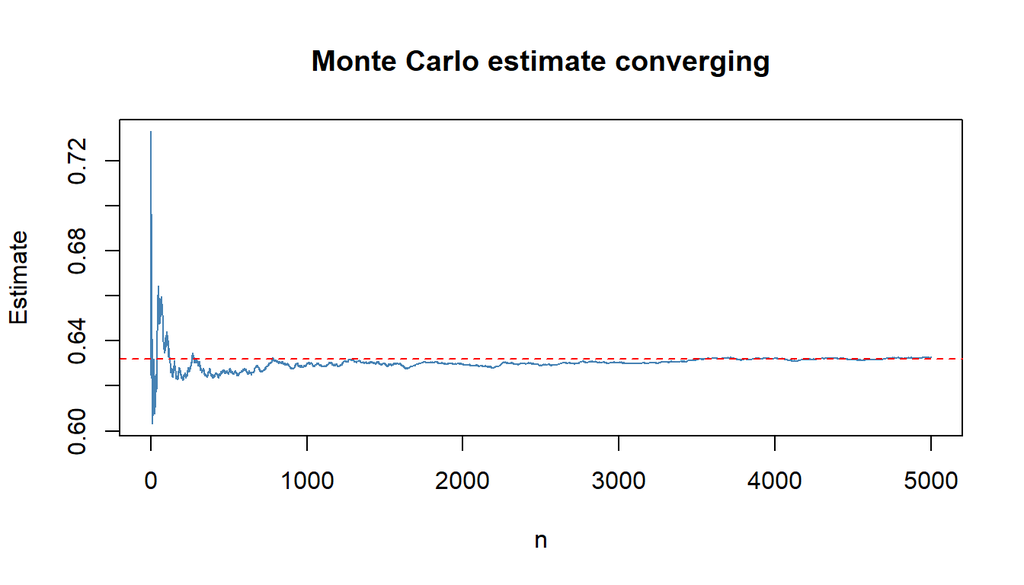

```r
n <- 5000
g <- exp(-runif(n))
running <- cumsum(g) / seq_len(n)

plot(running, type = "l", col = "steelblue", xlab = "n", ylab = "Estimate",
     main = "Monte Carlo estimate converging")
abline(h = 1 - exp(-1), col = "red", lty = 2)
```

## 2.4 Example 2: a probability

Estimate $P(U_1 + U_2 > 1.5)$ for independent $U_1, U_2 \sim \text{Uniform}(0,1)$. Elementary geometry gives the true value $0.125$.

```r
n <- 100000
u1 <- runif(n)
u2 <- runif(n)

hit <- (u1 + u2) > 1.5        # TRUE/FALSE for each draw
c(estimate = mean(hit), se = sd(hit) / sqrt(n), truth = 0.125)
```

```
##    estimate          se       truth
## 0.124780000 0.001045041 0.125000000
```

# 3 Importance Sampling

## 3.1 The problem

Suppose $\theta = P(Z > 4)$ with $Z \sim N(0,1)$. The event is very rare, with probability about $3 \times 10^{-5}$. With 10,000 draws, plain Monte Carlo usually sees **no hits at all** and returns exactly 0.

For a small probability $\theta$, the relative error of plain Monte Carlo is

$$\frac{\text{SE}}{\theta} \approx \frac{1}{\sqrt{n\theta}},$$

so you need $n \gg 1/\theta$ draws.

## 3.2 The idea

Sample from a different density $p$ that visits the important region often. Then correct each draw with a **weight**:

$$\hat\theta_{IS} = \frac{1}{n}\sum_{i=1}^n g(Y_i)\,w(Y_i),
\qquad w(y)=\frac{f(y)}{p(y)}, \qquad Y_i \sim p$$

This is still unbiased, because $E_p[g(Y)\,f(Y)/p(Y)] = \int g f\,dy = \theta$. The only requirement is that $p(y) > 0$ wherever $g(y)f(y) \neq 0$.

## 3.3 How to choose $p$

The variance is smallest when $p \propto |g|\,f$. You can’t sample from that exactly, because it needs the answer you are looking for. So the rule of thumb is to **pick $p$ shaped like $|g|f$**. For a tail probability, that means shifting the density toward the tail.

## 3.4 Method

1. Choose a proposal $p$ that puts more mass on the important region, with tails at least as heavy as $f$’s.
2. Draw $Y_1,\dots,Y_n$ from $p$.
3. Compute the weights $w_i = f(Y_i)/p(Y_i)$.
4. Compute the values $g(Y_i)\,w_i$.
5. The estimate is their mean, and the SE is their standard deviation divided by $\sqrt n$.

## 3.5 Example 3: a rare event with importance sampling

For $P(Z>4)$, use the proposal $N(4,1)$, which is centred at the threshold.

```r
n <- 10000
a <- 4

# Plain Monte Carlo
x <- rnorm(n)
g_naive <- as.numeric(x > a)

# Importance sampling
y <- rnorm(n, mean = a)                 # draw from p = N(4, 1)
w <- dnorm(y) / dnorm(y, mean = a)      # w = f / p
g_is <- (y > a) * w

data.frame(
  method   = c("Plain MC", "Importance"),
  estimate = c(mean(g_naive), mean(g_is)),
  se       = c(sd(g_naive) / sqrt(n), sd(g_is) / sqrt(n)),
  truth    = 1 - pnorm(a)
)
```

```
##       method     estimate           se        truth
## 1   Plain MC 1.000000e-04 1.000000e-04 3.167124e-05
## 2 Importance 3.187168e-05 6.772927e-07 3.167124e-05
```

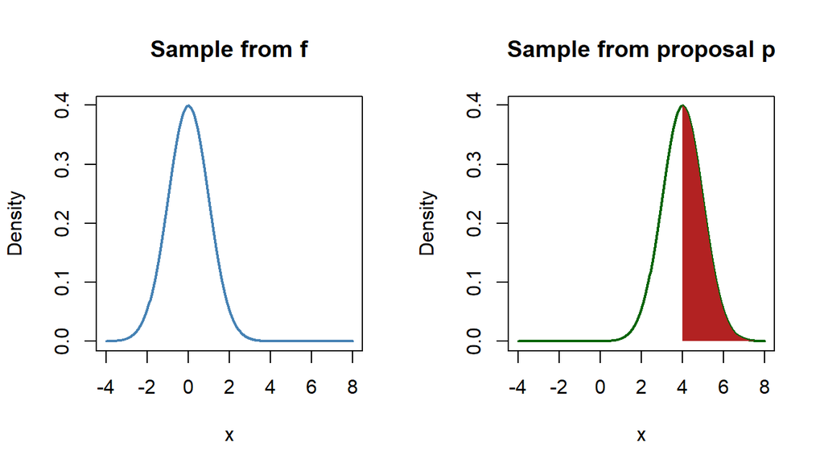

Left: f = N(0,1) rarely reaches the shaded tail. Right: the proposal N(4,1) reaches it half the time.

## 3.6 Check the weights

If a few weights are huge and the rest are tiny, the proposal is a bad match. A quick check is the **effective sample size**:

$$n_{\text{eff}} = \frac{(\sum_i w_i)^2}{\sum_i w_i^2}$$

If $n_{\text{eff}}$ is much smaller than $n$, be suspicious of the estimate.

```r
w_all <- w * (y > a)                    # weights on the draws that matter
c(n = n, n_eff = sum(w_all)^2 / sum(w_all^2))
```

```
##         n     n_eff
## 10000.000  1813.094
```

# 4 Self-Normalized Importance Sampling

Sometimes $f$ is known only up to a constant: $f(x) = \tilde f(x)/c$ with $c$ unknown. This is typical for Bayesian posteriors. The constant cancels if you divide by the sum of the weights:

$$\hat\theta_{SNIS} = \frac{\sum_i g(Y_i)\,\tilde w_i}{\sum_i \tilde w_i},
\qquad \tilde w_i = \frac{\tilde f(Y_i)}{p(Y_i)}$$

It is slightly biased for finite $n$, but consistent.

## 4.1 Example 4: unknown normalizing constant

Take the unnormalized target $\tilde f(x)=e^{-x^2/2}$ and estimate $E[X^2]$. The true value is $1$, because the target is $N(0,1)$. Use the proposal $N(0, 2^2)$.

```r
n <- 50000
y <- rnorm(n, 0, 2)                       # draws from p
w <- exp(-y^2 / 2) / dnorm(y, 0, 2)       # unnormalized weights

sum(y^2 * w) / sum(w)                     # SNIS estimate (truth = 1)
```

```
## [1] 1.000764
```

We never used the constant $\sqrt{2\pi}$.

# 5 Summary

|  | Monte Carlo | Importance sampling |
| --- | --- | --- |
| Draw from | $f$ | $p$ (chosen by you) |
| Estimate | mean of $g(X)$ | mean of $g(Y)\,f(Y)/p(Y)$ |
| SE | $s/\sqrt n$ | $s/\sqrt n$ (of weighted values) |
| Best for | simple or high-dimensional integrals | rare events, high variance |
| Best $p$ |  | $\propto \lvert g\rvert f$ |

**Tips**

- Always report a standard error.
- The proposal’s tails must be at least as heavy as the target’s. Otherwise the weights can have infinite variance.
- Check the weights or $n_{\text{eff}}$.
- Use self-normalized weights when the density is known only up to a constant.
- For smooth, low-dimensional integrals, quadrature is faster. Monte Carlo wins as the dimension grows.

# 6 Exercises

1. Estimate $\int_0^1 x^2\,dx$ by Monte Carlo and give a 95% interval. The true value is $1/3$.
2. Estimate $\pi$ by simulation. Draw $(U_1,U_2)$ uniform on the unit square and use $4 \times P(U_1^2+U_2^2<1)$.
3. Estimate $P(Z>3)$ both ways. What is the ratio of the variances?
4. In Example 3, change the proposal to $N(2,1)$ and then to $N(6,1)$. Compare the SE and $n_{\text{eff}}$.
5. Use a proposal with a lighter tail than the target (target $t_3$, proposal $N(0,1)$) to estimate $E[X^2]$. Look at the weights.